# Abundant species dynamics from benthic surveys

An Bui

1/31/2022

# 0. set up

```r
# source the cleaning/summarizing script, which sources the set up
source(here::here("code", "01_cleaning-and-summarizing.R"))
```

# 1. Biomass

## a. Guiding questions

What’s the percent community biomass that can be attributed to:  
1. *Laminariales*, and  
2. the 11 abundant species from Miller et al.?

Data question: what is the difference between the percent cover data and the percent cover that’s in the column in the biomass data?

Stray thoughts: introduced/native species trait column?

## b. Test case: SCTW from 3 different sampling points

To make sure the code was working, I tested this out with “SCTW_2010-07-29”, “SCTW_2016-07-20”, and “SCTW_2020-07-29”. The issue comes from scenarios where species were counted at more than one transect - for example, at SCTW_2020-07-29, EC was at both transect 2 and 3, but I only want the dry/wet biomass for EC for the whole survey.

When I create the data frame, there are then “duplicate” observations for total species biomass for EC because it was present at both transects. To fix this, I filtered the data frame for unique observations of the total and percent biomass calculations and double checked the total dry percent to make sure everything added up to 1.

### i. Calculations

```r
test <- biomass %>%
  filter(sample_ID %in% c("SCTW_2010-07-29", "SCTW_2016-07-20", "SCTW_2020-07-29")) %>%
  select(sample_ID, site, year, date, sp_code, dry_gm2, wm_gm2) %>%
  # create a new column where total biomass for the whole survey is calculated
  group_by(site, year) %>%
  mutate(total_dry = sum(dry_gm2),
         total_wet = sum(wm_gm2)) %>%
  ungroup() %>%
  # create a new column where total biomass for the species for the whole survey is calculated
  group_by(site, year, sp_code) %>%
  mutate(total_sp_dry = sum(dry_gm2),
         total_sp_wet = sum(wm_gm2)) %>%
  ungroup() %>%
  # create a new column where percent of total biomass per survey for each species is calculated
  mutate(percent_sp_dry = total_sp_dry/total_dry,
         percent_sp_wet = total_sp_wet/total_wet) %>%
  # double check to make sure the percents worked out...
  select(sample_ID, site, year, date, sp_code,
         # values that need to be unique:
         total_sp_dry, total_sp_wet, percent_sp_dry, percent_sp_wet) %>%
  unique() %>%
  group_by(sample_ID) %>%
  mutate(total_percent = sum(percent_sp_dry),
         total_percent_wet = sum(percent_sp_wet)) %>%
  # join with coarse traits data frame, which includes taxonomy
  left_join(., coarse_traits, by = "sp_code")
```

### ii. Plots

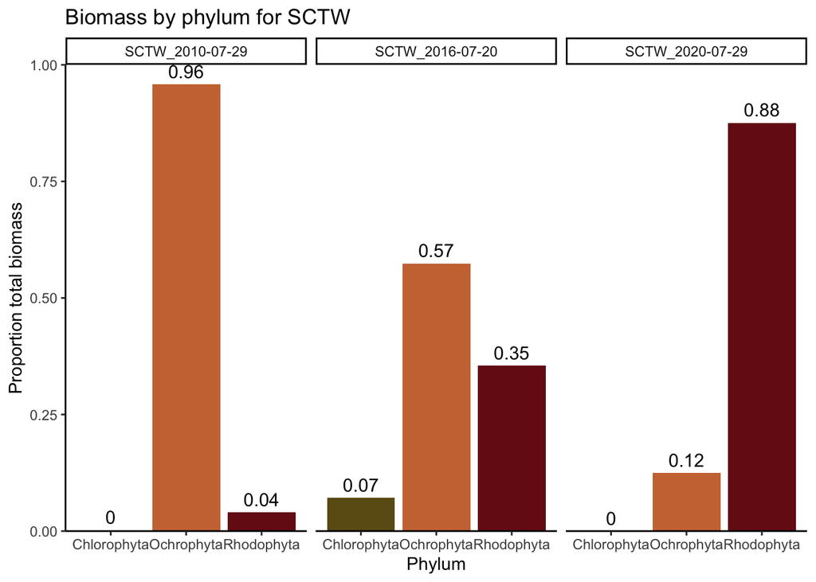

```r
# plot of proportion total biomass by phylum faceted by sampling date
ggplot(test) +
  aes(x = taxon_phylum, y = percent_sp_dry) +
  # calculating sum of proportion within stat_summary
  stat_summary(aes(fill = taxon_phylum),
               fun = "sum", geom = "bar") +
  # adding labels for sum values
  stat_summary(aes(label = round(..y.., 2)),
               fun = "sum", geom = "text",
               size = 4, vjust = -0.5) +
  scale_fill_manual(values = c("Chlorophyta" = chloro_col,
                               "Ochrophyta" = ochro_col,
                               "Rhodophyta" = rhodo_col)) +
  scale_y_continuous(limits = c(0, 1), expand = c(0, 0)) +
  facet_wrap(~sample_ID) +
  theme_classic() +
  theme(legend.position = "none") +
  labs(x = "Phylum",
       y = "Proportion total biomass",
       title = "Biomass by phylum for SCTW")
```

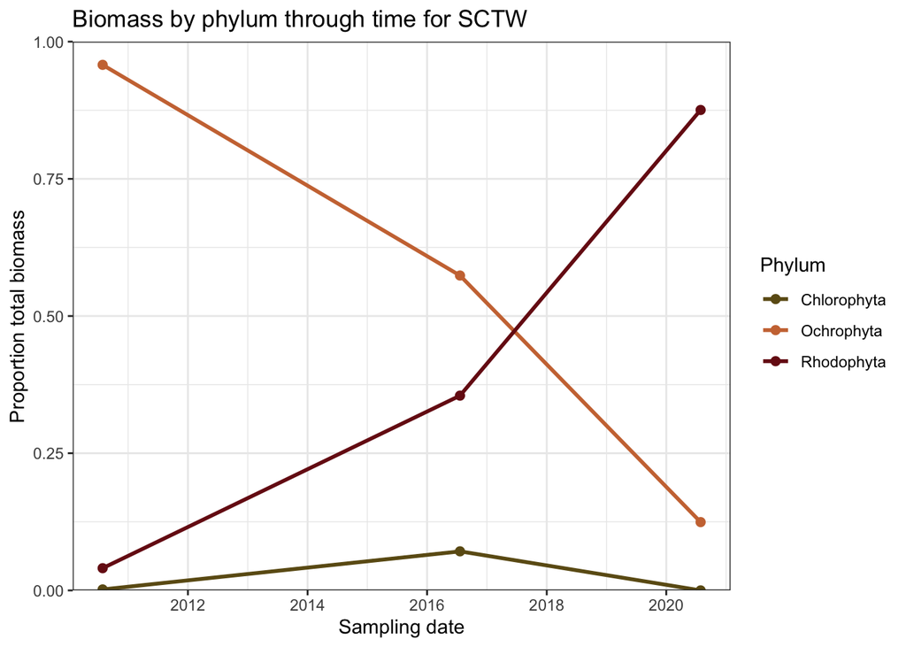

```r
# pretend timeseries
ggplot(test) +
  aes(x = date, y = percent_sp_dry) +
  # calculating sum of proportion within stat_summary
  stat_summary(aes(col = taxon_phylum),
               fun = "sum", geom = "line", size = 1) +
  stat_summary(aes(col = taxon_phylum),
               fun = "sum", geom = "point", size = 2) +
  scale_color_manual(values = c("Chlorophyta" = chloro_col,
                                "Ochrophyta" = ochro_col,
                                "Rhodophyta" = rhodo_col)) +
  scale_y_continuous(limits = c(0, 1), expand = c(0, 0)) +
  theme_bw() +
  # theme(legend.position = "none") +
  labs(x = "Sampling date",
       y = "Proportion total biomass",
       title = "Biomass by phylum through time for SCTW",
       col = "Phylum")
```

## c. Biomass data set

Since this worked, I felt comfortable doing this for the whole `biomass` data frame.

### i. Calculations

```r
prop_biomass <- biomass %>%
  select(sample_ID, site, year, date, sp_code, dry_gm2, wm_gm2) %>%
  # create a new column where total biomass for the whole survey is calculated
  group_by(site, year) %>%
  mutate(total_dry = sum(dry_gm2),
         total_wet = sum(wm_gm2)) %>%
  ungroup() %>%
  # create a new column where total biomass for the species for the whole survey is calculated
  group_by(site, year, sp_code) %>%
  mutate(total_sp_dry = sum(dry_gm2),
         total_sp_wet = sum(wm_gm2)) %>%
  ungroup() %>%
  # create a new column where percent of total biomass per survey for each species is calculated
  mutate(percent_sp_dry = total_sp_dry/total_dry,
         percent_sp_wet = total_sp_wet/total_wet) %>%
  # double check to make sure the percents worked out...
  select(sample_ID, site, year, date, sp_code,
         # values that need to be unique:
         total_sp_dry, total_sp_wet, percent_sp_dry, percent_sp_wet) %>%
  unique() %>%
  group_by(sample_ID) %>%
  mutate(total_percent = sum(percent_sp_dry),
         total_percent_wet = sum(percent_sp_wet)) %>%
  # join with coarse traits data frame, which includes taxonomy
  left_join(., coarse_traits, by = "sp_code")
```

### ii.

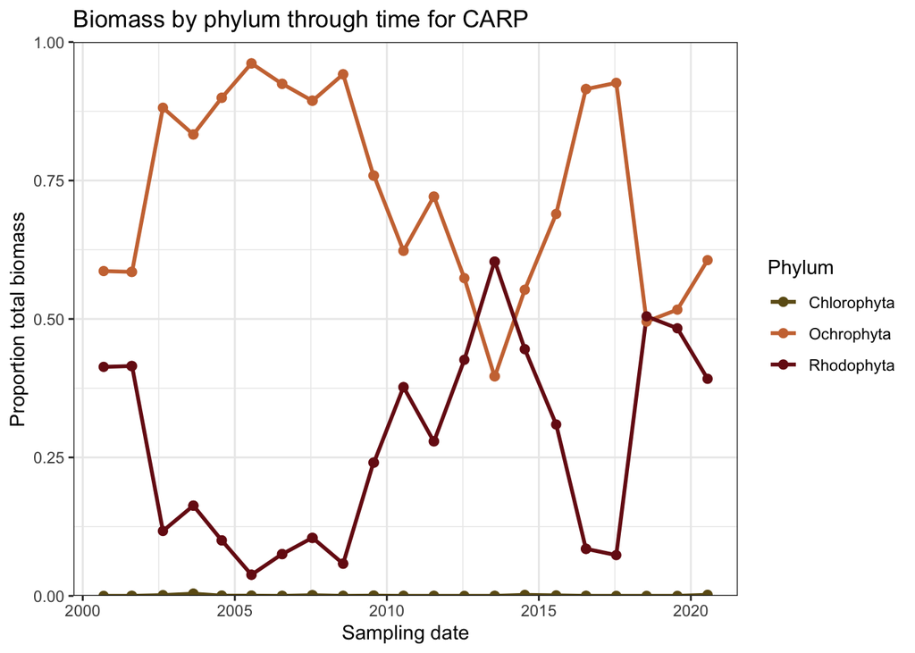

```r
ggplot(prop_biomass %>% filter(site == "CARP")) +
  aes(x = date, y = percent_sp_dry) +
  # calculating sum of proportion within stat_summary
  stat_summary(aes(col = taxon_phylum),
               fun = "sum", geom = "line", size = 1) +
  stat_summary(aes(col = taxon_phylum),
               fun = "sum", geom = "point", size = 2) +
  scale_color_manual(values = c("Chlorophyta" = chloro_col,
                                "Ochrophyta" = ochro_col,
                                "Rhodophyta" = rhodo_col)) +
  scale_y_continuous(limits = c(0, 1), expand = c(0, 0)) +
  theme_bw() +
  # theme(legend.position = "none") +
  labs(x = "Sampling date",
       y = "Proportion total biomass",
       title = "Biomass by phylum through time for CARP",
       col = "Phylum")
```

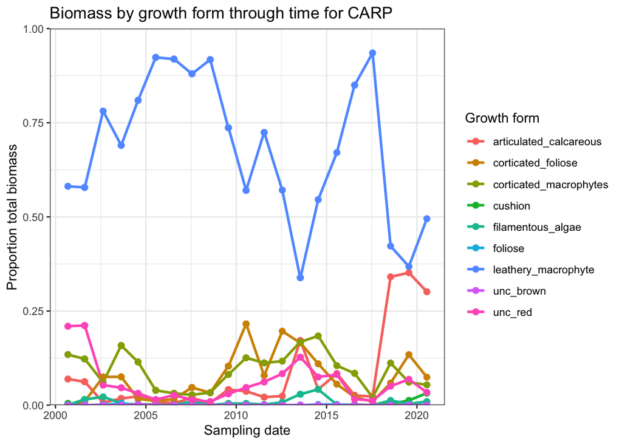

```r
ggplot(prop_biomass %>% filter(site == "CARP")) +
  aes(x = date, y = percent_sp_dry) +
  # calculating sum of proportion within stat_summary
  stat_summary(aes(col = growth_form),
               fun = "sum", geom = "line", size = 1) +
  stat_summary(aes(col = growth_form),
               fun = "sum", geom = "point", size = 2) +
  # scale_color_manual(values = c("Chlorophyta" = chloro_col,
  #                               "Ochrophyta" = ochro_col,
  #                               "Rhodophyta" = rhodo_col)) +
  scale_y_continuous(limits = c(0, 1), expand = c(0, 0)) +
  theme_bw() +
  labs(x = "Sampling date",
       y = "Proportion total biomass",
       title = "Biomass by growth form through time for CARP",
       col = "Growth form")
```